# Assignment_7_ARIMA_AryanPatel

Checking actual vs fitted

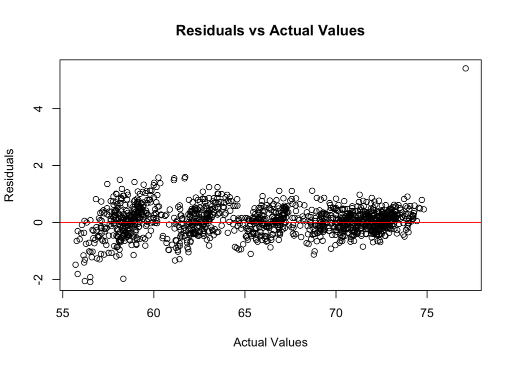

```r
actual <- auto_fit$x
fitted_vals <- auto_fit$fitted
resids <- auto_fit$residuals



plot(actual, resids,
     xlab = "Actual Values",
     ylab = "Residuals",
     main = "Residuals vs Actual Values")
abline(h = 0, col="red")
```

Forecasting 5 months ahead and plotting

```r
fc <- forecast(auto_fit,h = 5)
fc
```

```
##          Point Forecast    Lo 80    Hi 80    Lo 95    Hi 95
## Oct 2013       69.71934 69.08484 70.35384 68.74896 70.68973
## Nov 2013       65.31121 64.64106 65.98136 64.28630 66.33612
## Dec 2013       61.10316 60.40857 61.79775 60.04087 62.16545
## Jan 2014       59.71838 59.00678 60.42999 58.63008 60.80669
## Feb 2014       60.96785 60.24429 61.69141 59.86127 62.07444
```

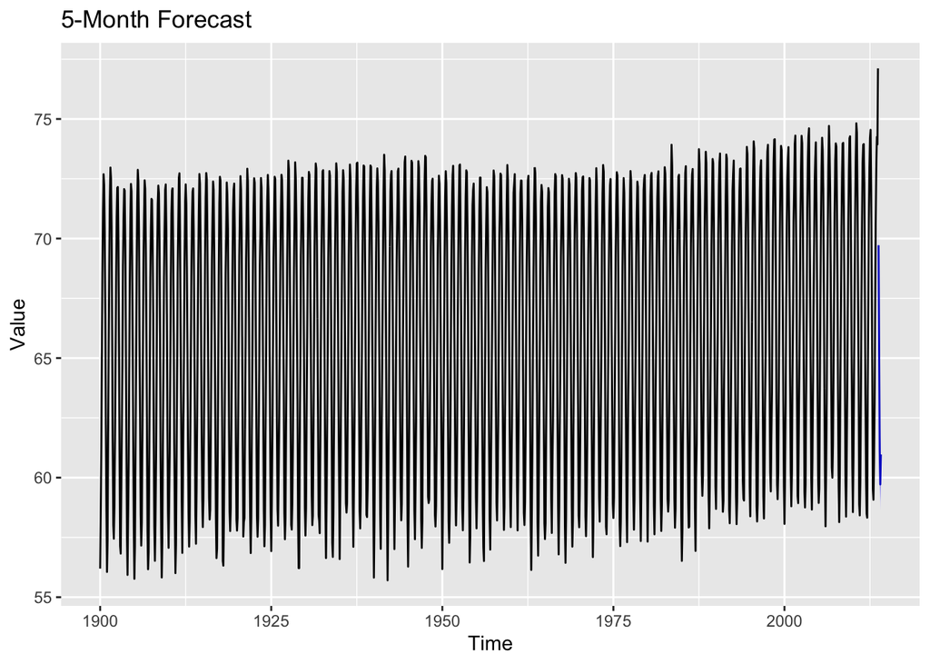

```r
autoplot(fc) +
  ggplot2::labs(
    title = "5-Month Forecast",
    x = "Time",
    y = "Value"
  )
```

Checking accuracy of the model

```r
auto_fit |>
accuracy()
```

```
##                      ME      RMSE       MAE        MPE      MAPE      MASE
## Training set 0.04970979 0.4920108 0.3591826 0.07077993 0.5611584 0.6597294
##                    ACF1
## Training set 0.01390369
```

From the metrics we can see the sarima model is performing very well on our data . MAE is only 0.359 meaning we are able to predict the global monthly average temperatures below 1 degree of error , based on in sample metrics . The mape is also 0.56 so less then 1 percent , 0.56% is our average difference in percent from the true value to our predicted . From these metrics we can see the model is performing very well and is very accurate in predicting the global monthly average temperature.